# 数据可视化 —— ggplot2 Data Visualization

zhongyu1@genomicn.cn

2019-11-4

## 前言

**ggplot2** 绘图系统是由 **Hadley Wickham** 创建的一个十分强大的可视化R包，是一套优雅的绘图语法。按照 **ggplot2** 的绘图理念，Plot(图)= data(数据集) + Geometry(几何对象) + Aesthetics(美学映射)： data: 数据集，主要是data frame  
Geometry: 几何对象，比如柱形图、直方图、散点图、线图、密度图等  
Aesthetics: 美学映射，比如将变量映射给x,y坐标轴，或者映射给颜色、大小、形状等图形属性

一张统计图形就是从**数据**（data）到**几何对象**（geometric object，缩写geom）的**图形属性**（aesthetic attribute，缩写aes）的一个映射。此外，图形中还可能包含数据的**统计变换**（statistical transformation，缩写stats），最后绘制在某个特定的**坐标系**（coordinate system，缩写coord）中，而**分面**（facet）则可以用来生成数据不同子集的图形。

### 绘图函数

- `qplot()`  
  快速绘图，类似base系统的`plot()`
- `ggplot()`  
  是ggplot2的核函数心，远比`qplot()`强大，可以绘制复杂的图形。直接调用`ggplot()`本身不能实现绘图，要在其基础上添加层。

### 安装及加载 ggplot2

```r
library(ggplot2)
library(esquisse)
# 提示没有 ggplot2 则运行 install.packages("ggplot2"") 进行安装
# 提示没有 esquisse 则运行 install.packages("esquisse") 或 remotes::install_github("dreamRs/esquisse") 进行安装
```

接下来以 diamonds 数据集为例，结合多种图形进行 ggplot2 的学习。

diamonds 为具有53940行和10个变量的数据框，其中包括：克拉（carat）、切工（cut）、颜色（color）、透明度（clarity）、深度（depth）、table、价钱（price）、长宽高（x，y，z）

我们先加载并查看下 diamonds 数据集的结构：

```r
data("diamonds")
head(diamonds)
```

```
## # A tibble: 6 x 10
##   carat cut       color clarity depth table price     x     y     z
##   <dbl> <ord>     <ord> <ord>   <dbl> <dbl> <int> <dbl> <dbl> <dbl>
## 1 0.23  Ideal     E     SI2      61.5    55   326  3.95  3.98  2.43
## 2 0.21  Premium   E     SI1      59.8    61   326  3.89  3.84  2.31
## 3 0.23  Good      E     VS1      56.9    65   327  4.05  4.07  2.31
## 4 0.290 Premium   I     VS2      62.4    58   334  4.2   4.23  2.63
## 5 0.31  Good      J     SI2      63.3    58   335  4.34  4.35  2.75
## 6 0.24  Very Good J     VVS2     62.8    57   336  3.94  3.96  2.48
```

因为数据记录太多不便于展示，所以先随机原始数据的一个子集。使用sample()函数从总行数中随机采样出1000个数，然后作为行索引从原始数据框中截取出采样的行。

```r
set.seed(1) # 设置随机种子点
plot_data <- diamonds[sample(nrow(diamonds), 1000),]
dim(plot_data) # 查看数据维度
```

```
## [1] 1000   10
```

```r
head(plot_data)
```

```
## # A tibble: 6 x 10
##   carat cut       color clarity depth table price     x     y     z
##   <dbl> <ord>     <ord> <ord>   <dbl> <dbl> <int> <dbl> <dbl> <dbl>
## 1  1.51 Fair      J     SI2      65.1  59    5801  7.13  7.09  4.63
## 2  1.27 Premium   G     VS2      61    60    8549  6.93  6.97  4.24
## 3  0.41 Ideal     D     SI1      63    53     744  4.74  4.79  3
## 4  0.36 Ideal     H     SI1      62.3  53     538  4.57  4.61  2.86
## 5  1.05 Premium   F     SI1      62.8  59    4879  6.43  6.4   4.03
## 6  0.55 Very Good F     VS1      61.2  56.4  1975  5.28  5.33  3.25
```

### qplot()

`qplot()` 类似于R基本绘图函数 `plot()`,可以快速绘制常见的几种图形：散点图(point)、箱线图(boxplot)、小提琴图(violin)、直方图(histogram)以及密度曲线图(density)。其绘图格式为：`qplot(x, y=NULL, data, geom="auto", main = NULL, xlab = NULL, ylab = NULL, ...)`  
其中:

- x, y: x轴的对应的变量，y轴对应的变量
- data：数据集
- geom：几何图形，变量x,y同时指定的话默认为散点图，只指定x的话默认为直方图
- main, xlab, ylab：分别为图的标题，x 轴 label 和 y 轴 label。

#### 散点图

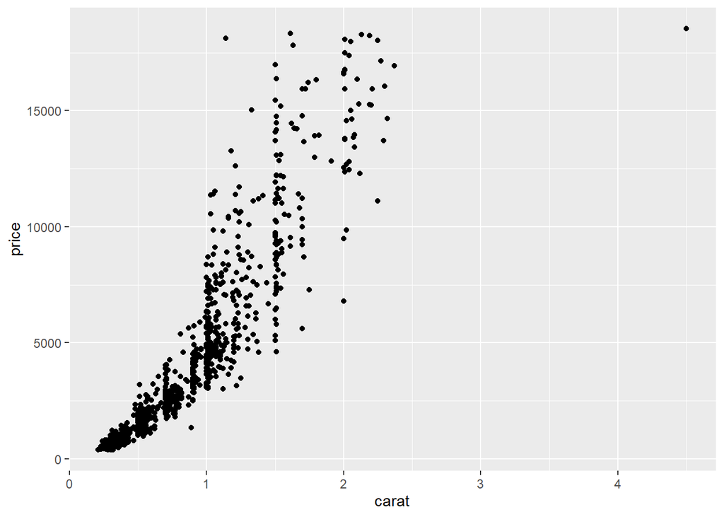

```r
qplot(carat, price, data = plot_data) # 价格与克拉的关系
```

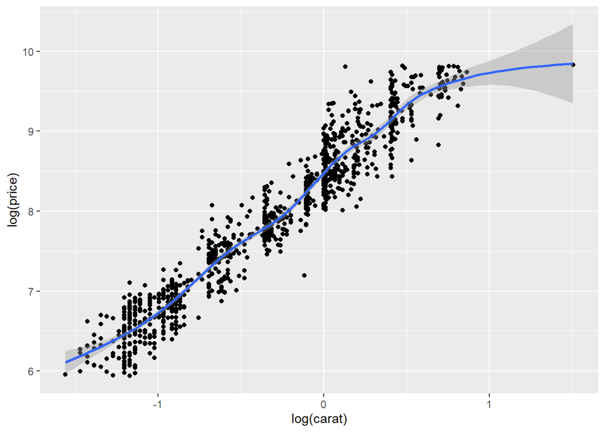

```r
qplot(log(carat), log(price), data = plot_data, geom = c("point","smooth")) # 对数变换并添加拟合曲线
```

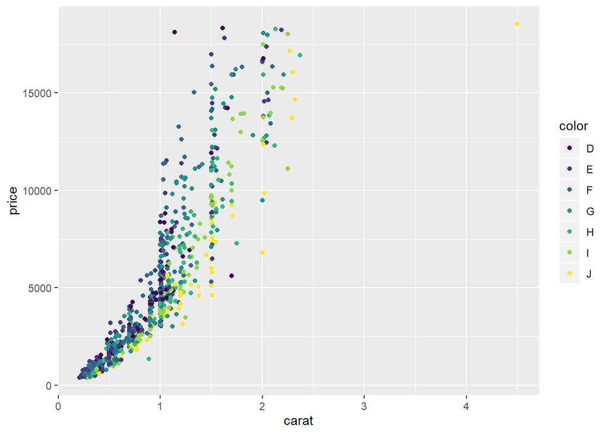

```r
qplot(carat, price, data = plot_data, color = color) # 用不同颜色标记颜色
```

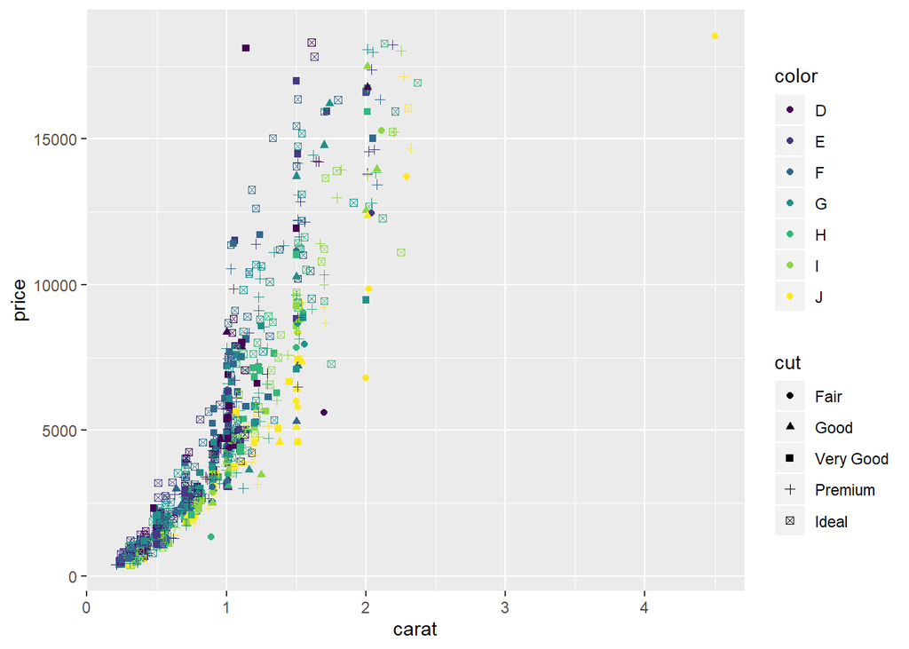

```r
qplot(carat, price, data = plot_data, color = color, shape = cut) # 用不同形状标记切工
```

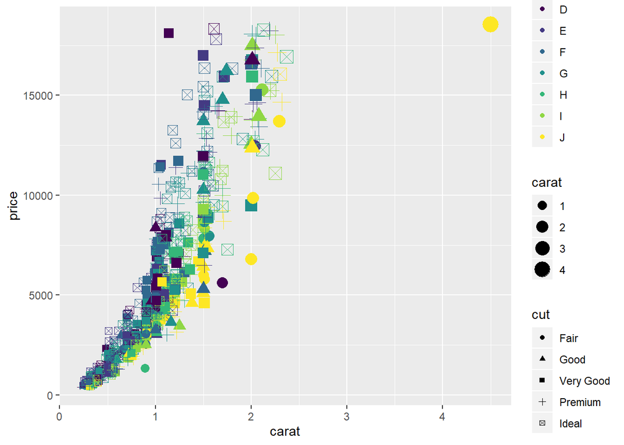

```r
qplot(carat, price, data = plot_data, color = color, shape = cut, size = carat) # 用不同大小标记克拉
```

#### 直方图与密度曲线

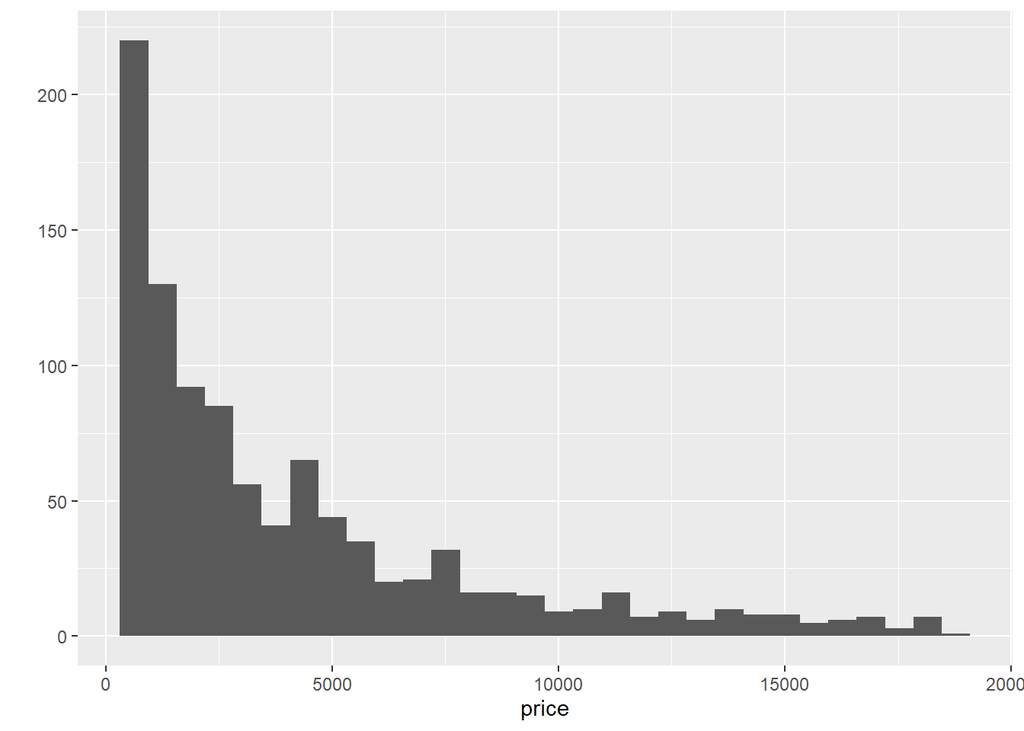

```r
# 价格的分布
qplot(price, data = plot_data) # 直方图
```

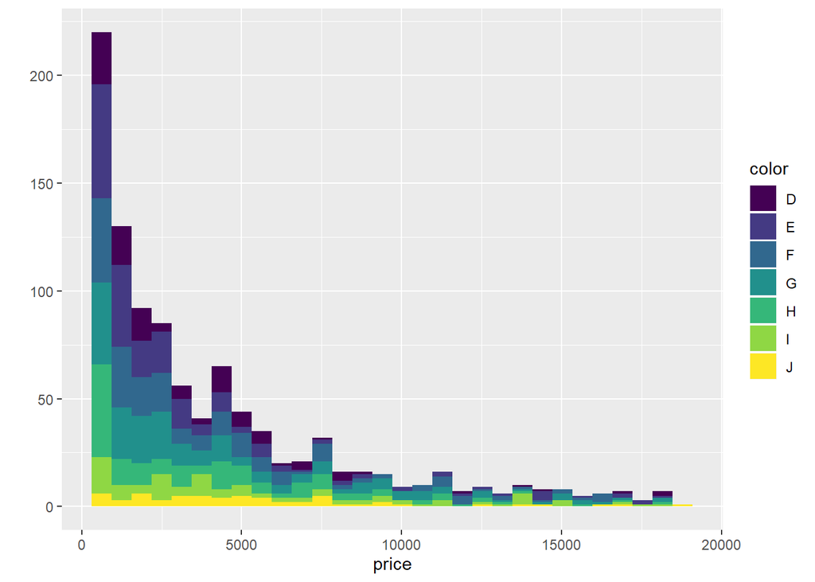

```r
qplot(price, data = plot_data, fill = color) # 用不同颜色填充标记颜色
```

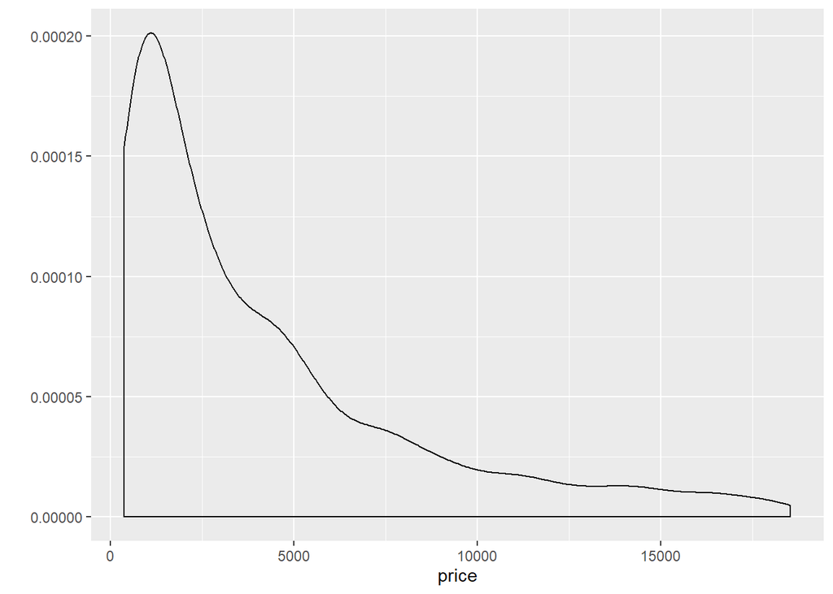

```r
qplot(price, data = plot_data, geom = "density") # 密度曲线
```

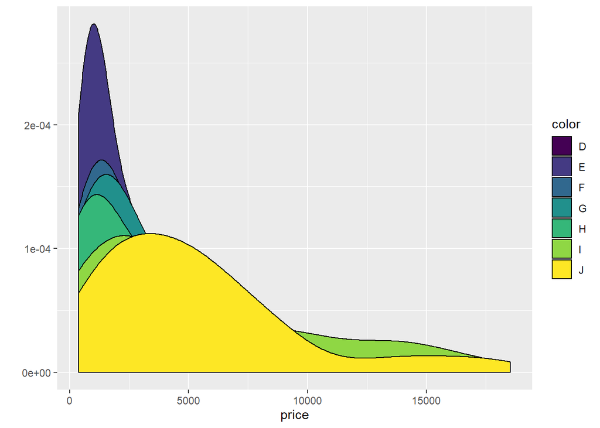

```r
qplot(price, data = plot_data, geom = "density", fill = color) # 用不同颜色填充标记颜色
```

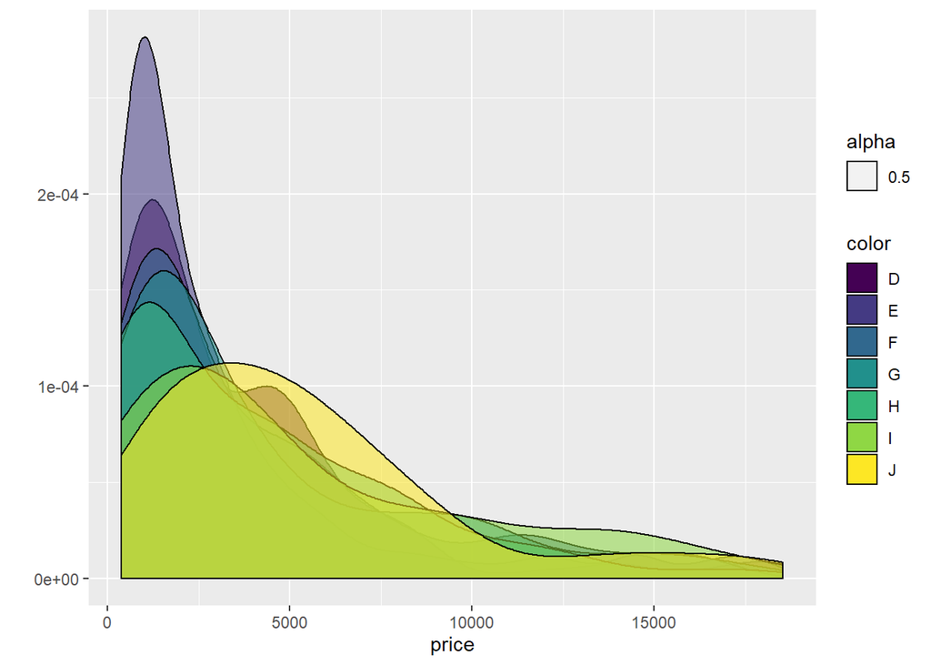

```r
qplot(price, data = plot_data, geom = "density", fill = color, alpha = 0.5) # 设置透明度
```

`qplot()` 相当于 `ggplot()` 的精简版，方便快速画图。但作为初学者，理解和熟练掌握 `ggplot()` 后 `qplot()` 自然也就信手拈来。推荐初学者使用 `ggplot()`,以便理解 ggplot2 的绘图语法，以及层（layer）的概念。

### ggplot()

ggplot2 的绘图有一个图层的理念，每个图层可以有自己的图形对象和图形属性，通过“+”将不同图层叠加起来生成最后的统计图形。如果将数据及美学属性定义在 `ggplot()` 中，那么所有图层都可以共用这个数据；如果将数据定义在 `geom_xxx()` 中，那么这个数据就只供这个几何对象使用。

我们再来回顾下 ggplot2 基本要素:

- 数据（data）和映射（ase）
- 几何对象（geom_）
- 标尺（scale_）
- 统计变换（stat_）
- 坐标系统（coord_）
- 分面（facet_）
- 标签 （labs）
- 主题（theme_）

ggplot2 绘图过程就是各个要素图层的叠加产生。掌握了数据、几何对象、图形属性和图层的概念后，我们就可以用 `ggplot()` 开始绘制常见的统计图形了。

#### 散点图 —— geom_point()

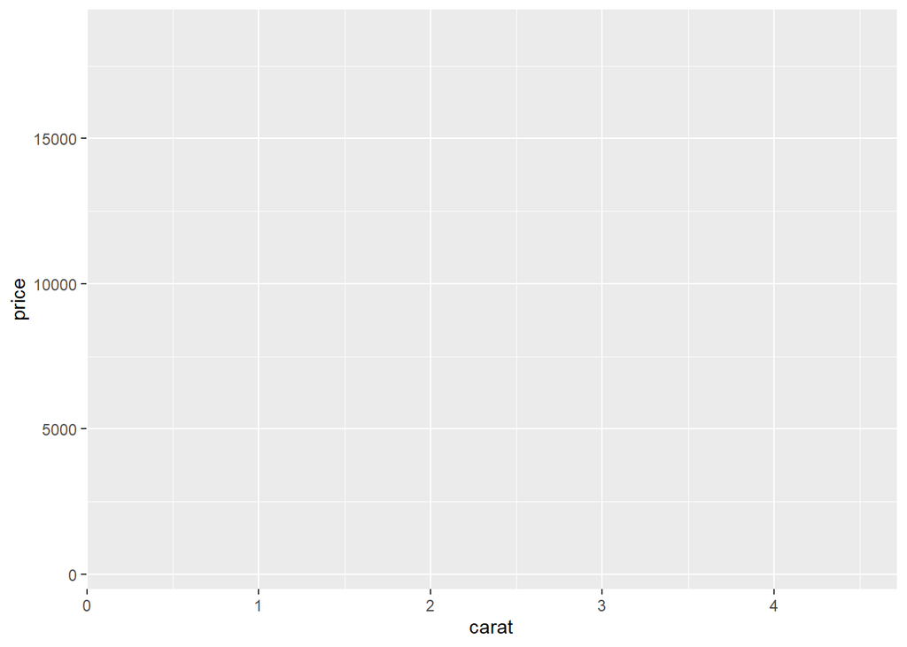

```r
# 价格和克拉的关系
ggplot(plot_data, aes(x=carat, y=price)) # 直接调用`ggplot()`本身不能实现绘图，要在其基础上添加层。仅有数据及美学属性映射，没有几何对象层。
```

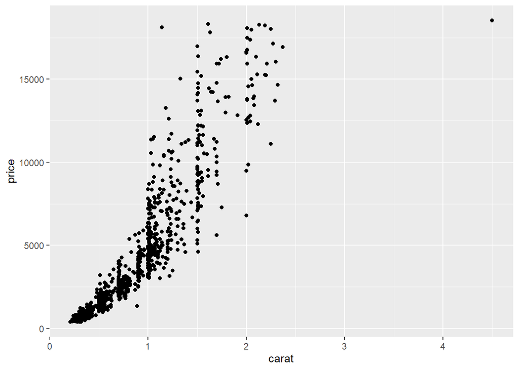

```r
ggplot(plot_data, aes(x=carat, y=price))+ geom_point() # 用 + 加上几何对象层
```

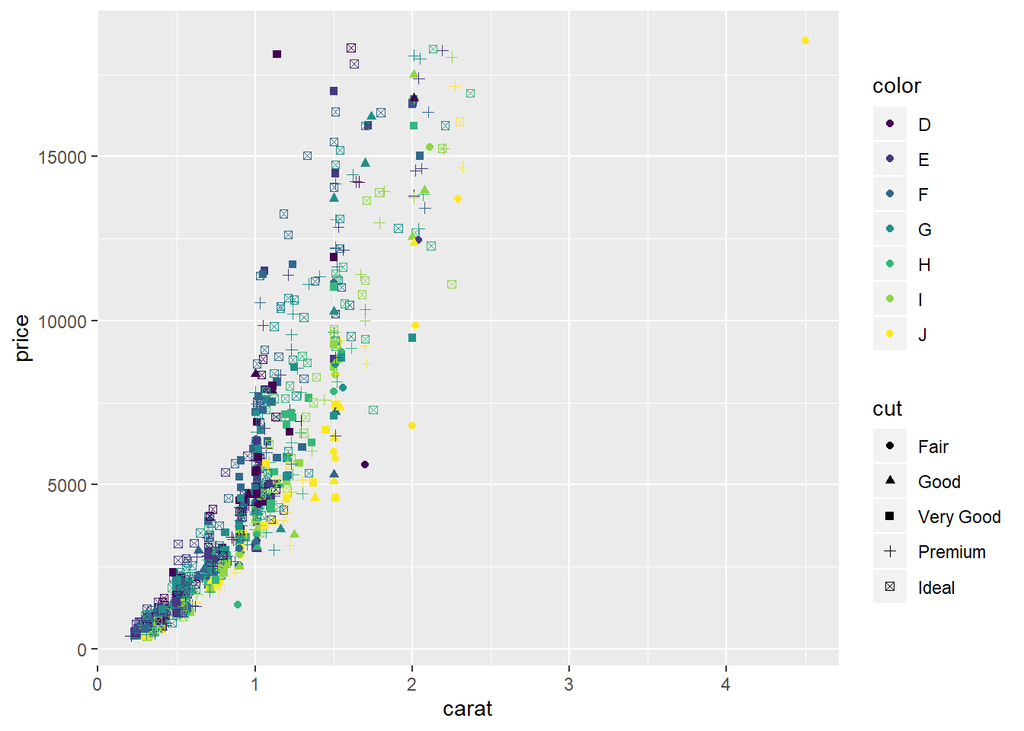

```r
ggplot(plot_data, aes(x=carat, y=price, color=color, shape=cut)) + geom_point() # 加入color 和 cut 的信息
```

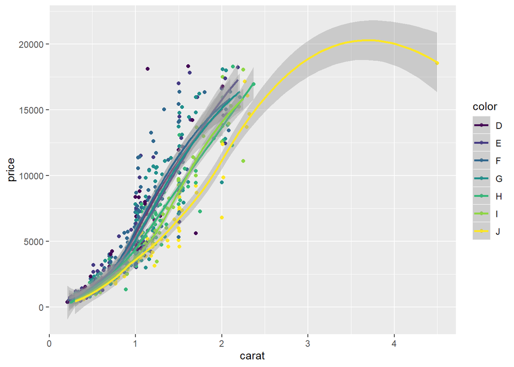

```r
# 加入统计层：拟合曲线
ggplot(plot_data, aes(x=carat, y=price, color=color)) + geom_point() + stat_smooth()
```

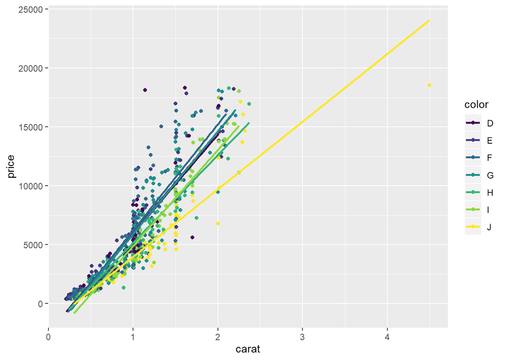

```r
# method = "lm" 线性拟合, se = F 取消显示线性区间
ggplot(plot_data, aes(x=carat, y=price, color=color)) + geom_point() + stat_smooth(method = "lm", se = F)
```

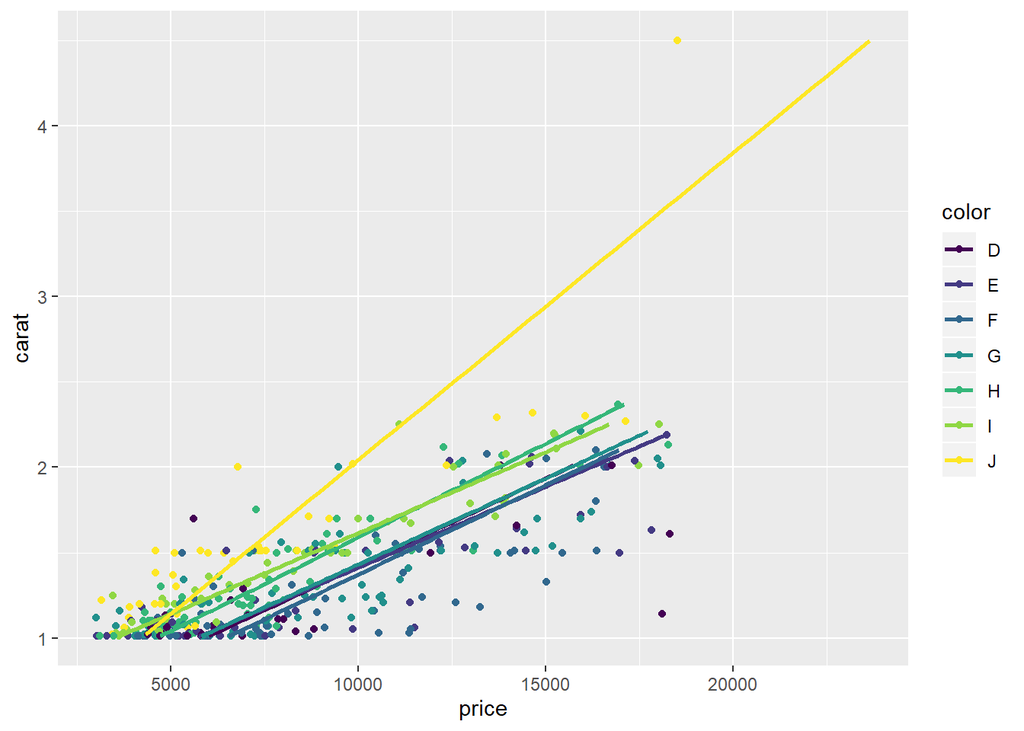

```r
# 添加坐标设置
ggplot(subset(plot_data, carat > 1), aes(x=carat, y=price, color=color)) +
  geom_point() +
  geom_smooth(method = "lm", se = F) + # method = "lm" 线性拟合, se = F 取消显示线性区间
  coord_flip() # 对换 x, y 轴
```

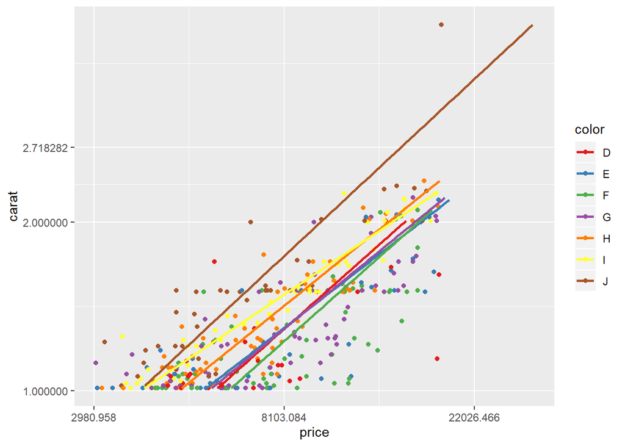

```r
# 添加标尺设置
ggplot(subset(plot_data, carat > 1), aes(x=carat, y=price, color=color)) +
  geom_point() +
  geom_smooth(method = "lm", se = F) + # method = "lm" 线性拟合, se = F 取消显示线性区间
  coord_flip() + # 对换 x, y 轴
  scale_color_brewer(palette = "Set1")+ # 设置颜色标尺
  scale_x_continuous(trans = "log") + # 对数据设置对数标尺
  scale_y_continuous(trans = "log")
```

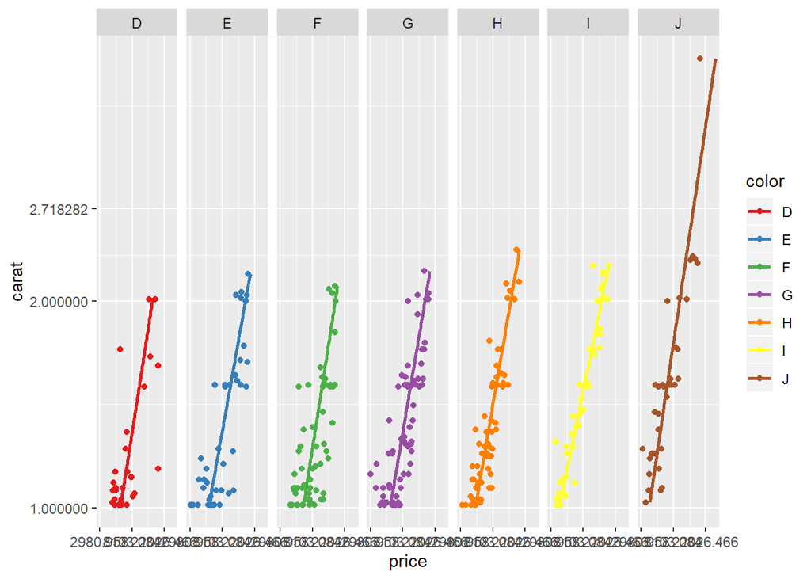

```r
# 添加分面设置 —— facet_grid(), facet_warp()
ggplot(subset(plot_data, carat > 1), aes(x=carat, y=price, color=color)) +
  geom_point() +
  geom_smooth(method = "lm", se = F) + # method = "lm" 线性拟合, se = F 取消显示线性区间
  coord_flip() + # 对换 x, y 轴
  scale_color_brewer(palette = "Set1")+ # 设置颜色标尺
  scale_x_continuous(trans = "log") + # 对数据设置对数标尺
  scale_y_continuous(trans = "log") +
  facet_grid(.~color) # 根据 color 按列进行分面
```

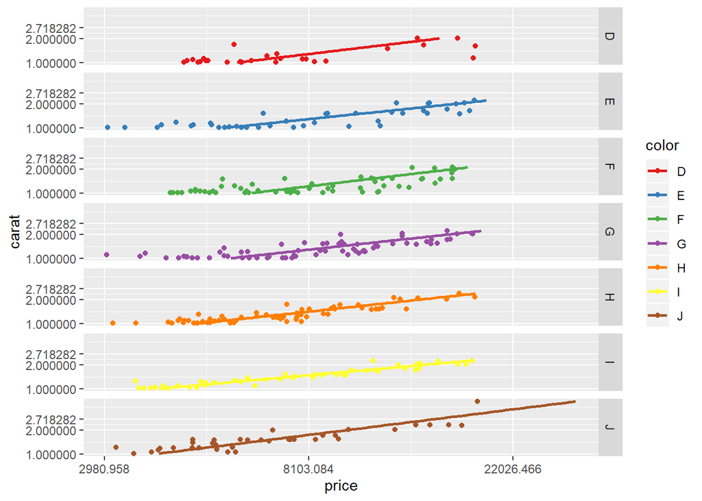

```r
ggplot(subset(plot_data, carat > 1), aes(x=carat, y=price, color=color)) +
  geom_point() +
  geom_smooth(method = "lm", se = F) + # method = "lm" 线性拟合, se = F 取消显示线性区间
  coord_flip() + # 对换 x, y 轴
  scale_color_brewer(palette = "Set1")+ # 设置颜色标尺
  scale_x_continuous(trans = "log") + # 对数据设置对数标尺
  scale_y_continuous(trans = "log") +
  facet_grid(color~.) # 根据 color 按行进行分面
```

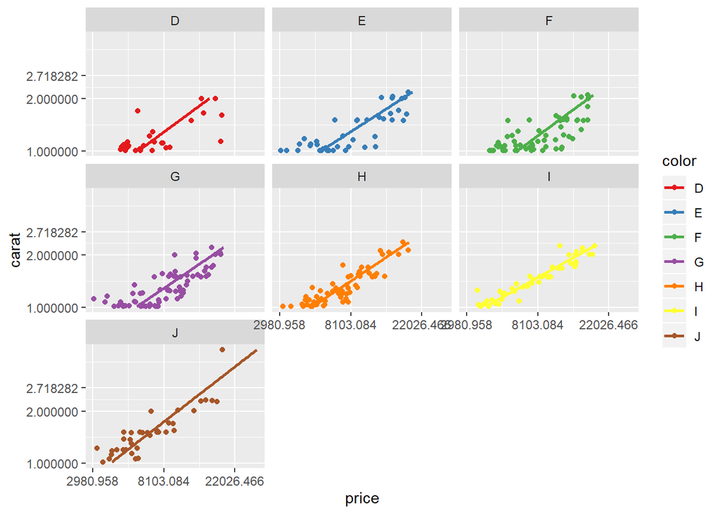

```r
ggplot(subset(plot_data, carat > 1), aes(x=carat, y=price, color=color)) +
  geom_point() +
  geom_smooth(method = "lm", se = F) + # method = "lm" 线性拟合, se = F 取消显示线性区间
  coord_flip() + # 对换 x, y 轴
  scale_color_brewer(palette = "Set1")+ # 设置颜色标尺
  scale_x_continuous(trans = "log") + # 对数据设置对数标尺
  scale_y_continuous(trans = "log") +
  facet_wrap(~color, nrow = 3) # 根据 color 进行分面,按照行列分布，可指定行数和列数
```

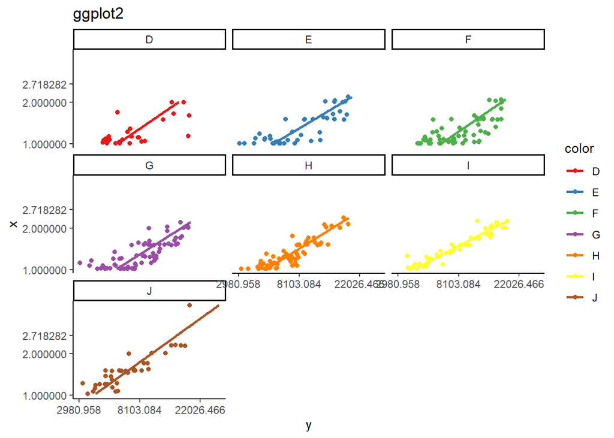

```r
# 设置标签与主题
ggplot(subset(plot_data, carat > 1), aes(x=carat, y=price, color=color)) +
  geom_point() +
  geom_smooth(method = "lm", se = F) + # method = "lm" 线性拟合, se = F 取消显示线性区间
  coord_flip() + # 对换 x, y 轴
  scale_color_brewer(palette = "Set1")+ # 设置颜色标尺
  scale_x_continuous(trans = "log") + # 对数据设置对数标尺
  scale_y_continuous(trans = "log") +
  facet_wrap(~color, nrow = 3)+ # 根据 color 进行分面,按照行列分布，可指定行数和列数
  labs(x = "x", y = "y", title = "ggplot2")+ # 设置标签
  theme_classic() # 设置主题
```

不同的几何对象，要求的属性会有些不同，这些属性也可以在几何对象映射时提供。通常把不同的图层中共用的映射提供给 `ggplot()` 函数，而某一几何对象才需要的映射参数提供给 `geom_xxx()` 函数。

接下来看一下各种常用的几何对象：`geom_histogram()`, `geom_density()`, `geom_bar()`, `geom_boxplot()`, `geom_violin()`, `geom_jitter()`

#### 直方图 —— geom_histogram()

直方图只需提供一个x变量，画出数据的分布。

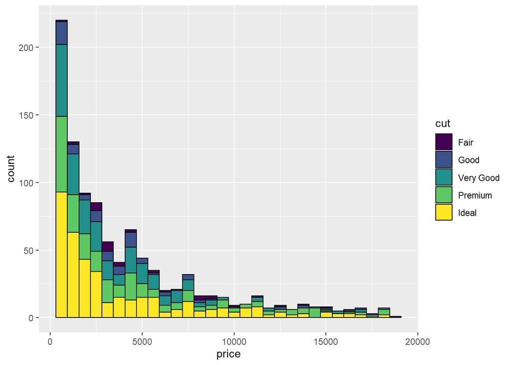

```r
ggplot(plot_data) + geom_histogram(aes(x=price, fill=cut), color="black")  # 属性在几何对象映射时提供
```

#### 密度曲线 —— geom_density()

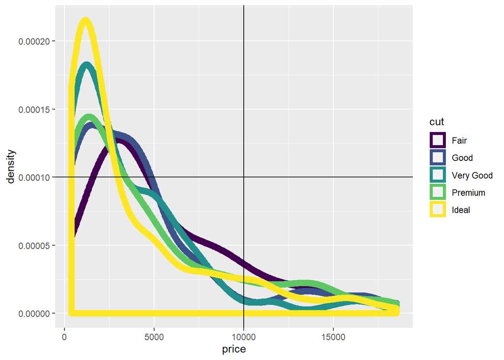

```r
ggplot(plot_data) +
  geom_density(aes(x=price, color=cut), fill=NA, size=3) + # 设置密度曲线颜色与宽度
  geom_vline(xintercept = 10000) + # 添加垂直线
  geom_hline(yintercept = 0.0001) # 添加水平线
```

#### 条形图 —— geom_bar()

柱状图非常适合于画分类变量。在这里以切工（cut）变量为例。按照不同切割质量的钻石的数目画柱状图。

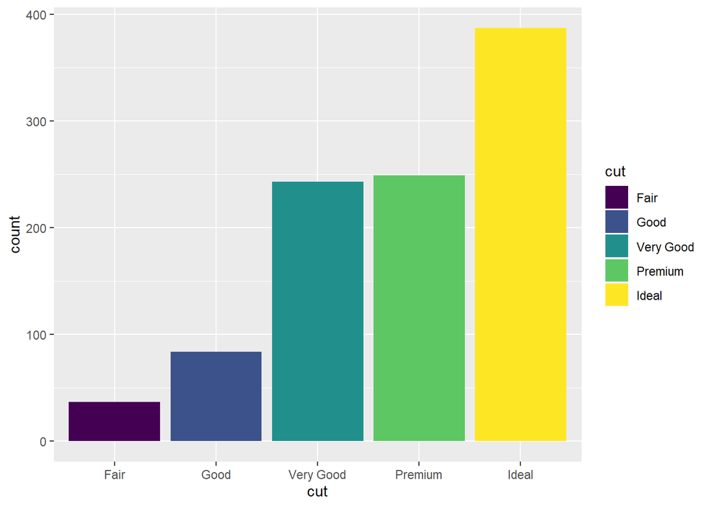

```r
# 用不同颜色标记 cut
ggplot(plot_data) +
  geom_bar(aes(x = cut, fill = cut))
```

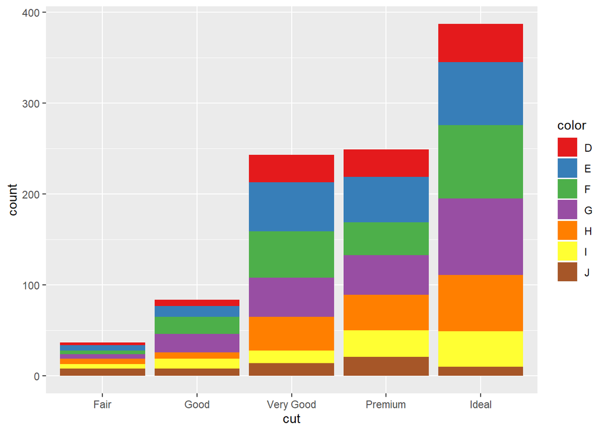

```r
# fill的功能映射到 color 变量
ggplot(plot_data) +
  geom_bar(aes(x = cut, fill = color))+ # 用不同颜色标记 color
  scale_fill_brewer(palette = "Set1")
```

堆叠条形图会通过位置(`position`)参数进行自动位置堆叠(“stack”)。如果您不想使用堆叠条形图，则可以使用 “dodge” 或 “fill” 。

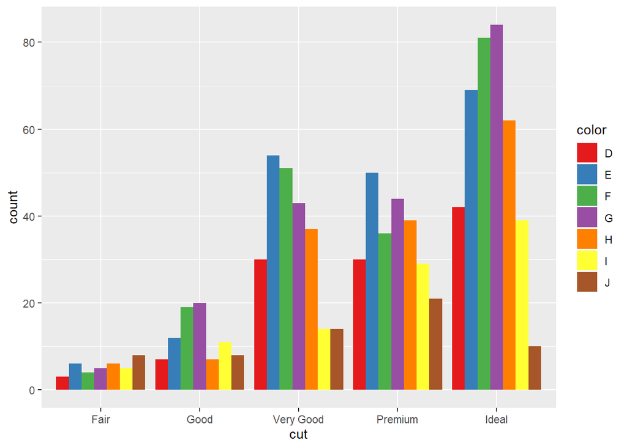

```r
# position = "dodge" 将重叠对象并排直接放在一起，便于比较。
ggplot(plot_data) +
  geom_bar(aes(x = cut, fill = color), position = "dodge")+ # 用不同颜色标记 color
  scale_fill_brewer(palette = "Set1")
```

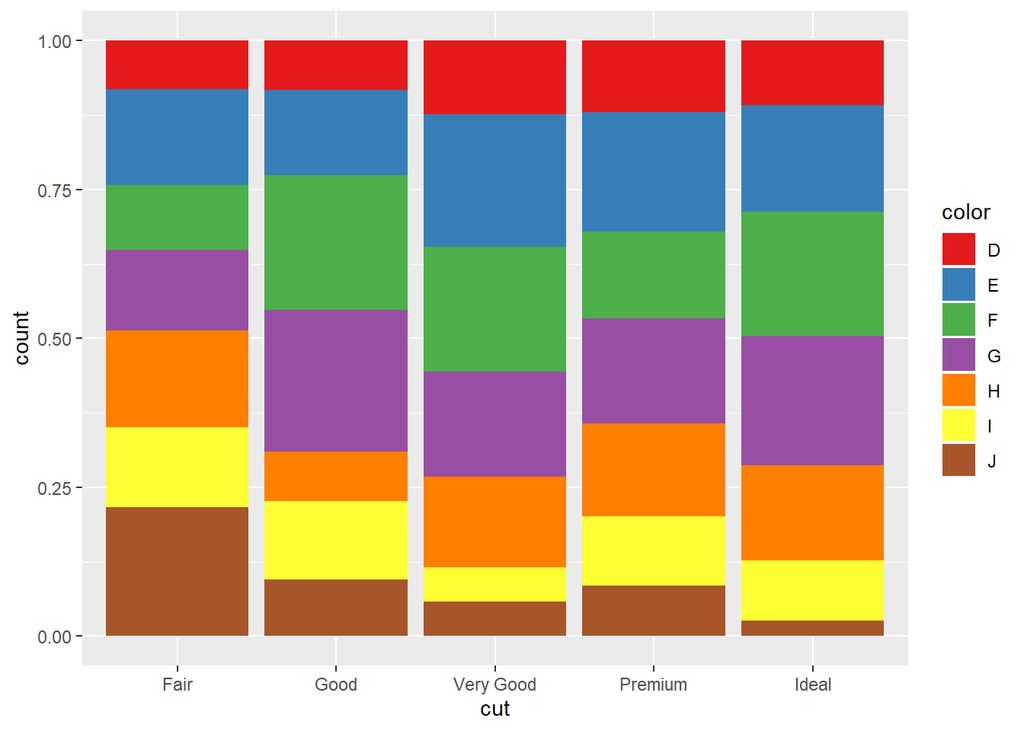

```r
# position = "fill" 和堆叠图类似，但是它可以使每组堆叠的条形都具有相同的高度，这样可以更容易地比较组间的比例。
ggplot(plot_data) +
  geom_bar(aes(x = cut, fill = color), position = "fill")+ # 用不同颜色标记 color
  scale_fill_brewer(palette = "Set1")
```

#### 箱线图 —— geom_boxplot()

箱线图可以很好得展示数据分布

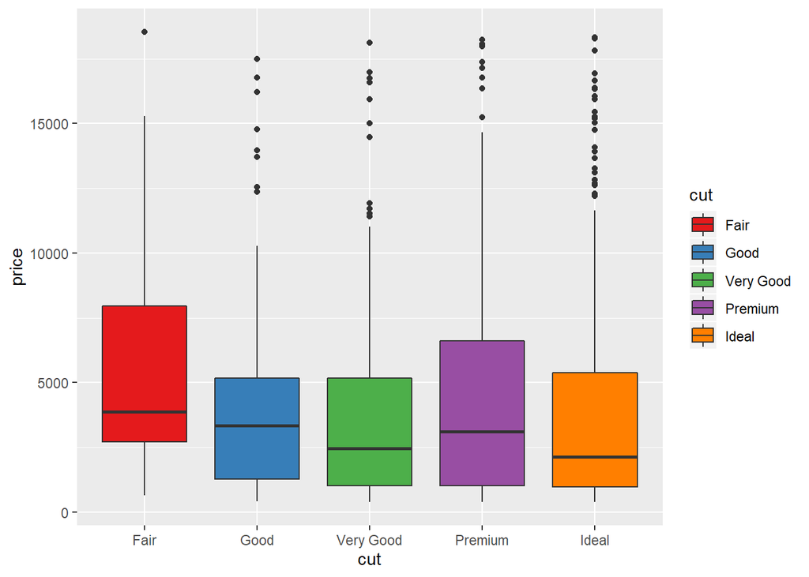

```r
ggplot(plot_data) +
  geom_boxplot(aes(x = cut, y = price, fill=cut))+ # 用不同颜色标记 cut
  scale_fill_brewer(palette = "Set1")
```

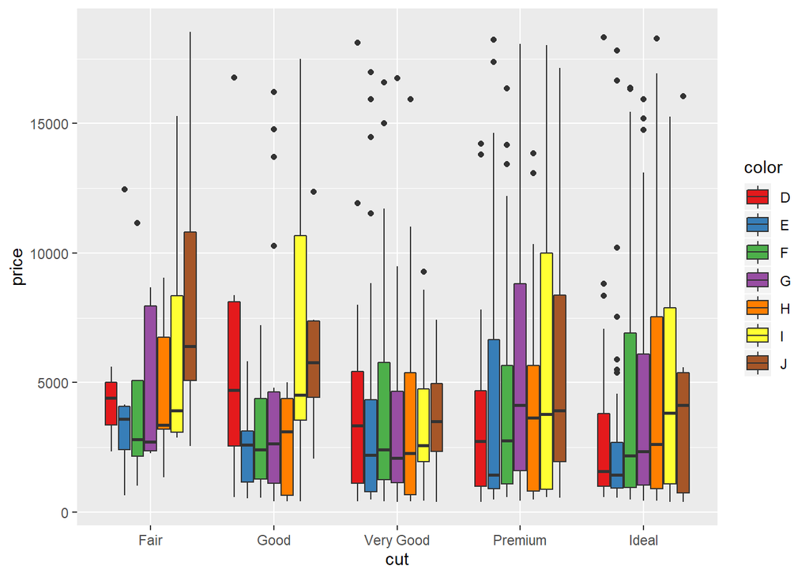

```r
ggplot(plot_data) +
  geom_boxplot(aes(x = cut, y = price, fill=color))+ # 用不同颜色标记 color
  scale_fill_brewer(palette = "Set1")
```

#### 小提琴图 —— geom_violin()

小提琴图是的箱线图变种，是箱线图与密度图的结合。在小提琴图中，纵向显示数据分布范围，在横向上数据越密集的区域越宽，越稀疏越窄。 扩展此图的一种方法是在其上添加一层单独的点

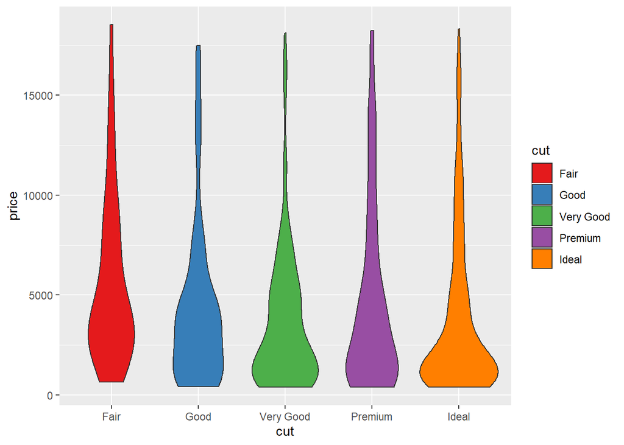

```r
ggplot(plot_data) +
  geom_violin(aes(x = cut, y = price, fill=cut))+ # 用不同颜色标记 cut
  scale_fill_brewer(palette = "Set1")
```

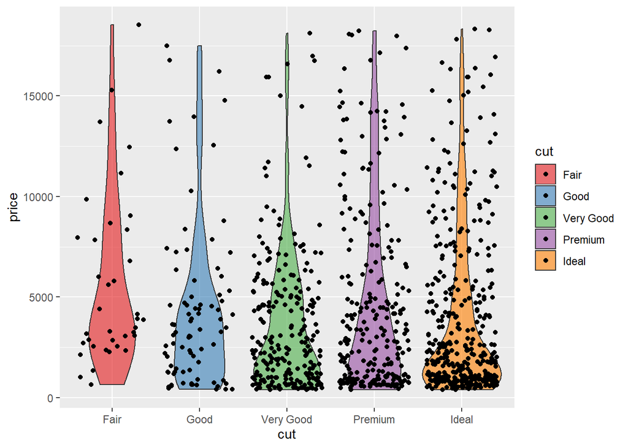

```r
# 扩展此图的一种方法是在其上添加一层单独的点
ggplot(plot_data,aes(x = cut, y = price, fill=cut)) +
  geom_violin(alpha=0.6)+ # 设置透明度
  geom_jitter()+ # 增加散点图层
  scale_fill_brewer(palette = "Set1")
```

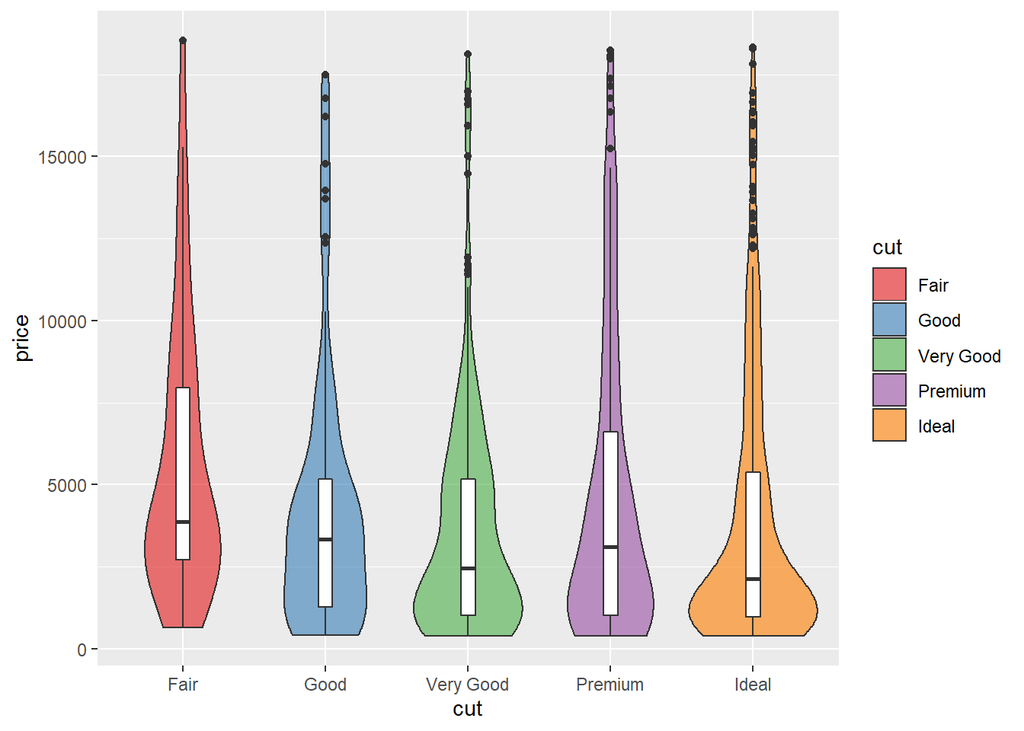

```r
# 扩展此图的另一种方法是在其上添加箱线图
ggplot(plot_data,aes(x = cut, y = price, fill=cut)) +
  geom_violin(alpha=0.6)+ # 设置透明度
  geom_boxplot(width=0.1, fill="white")+ # 增加箱线图图层，并设置宽度和颜色
  scale_fill_brewer(palette = "Set1")
```

## 总结

ggplot2 的优越性在于它创建了一套完整的绘图语法，相较于R自带的绘图语法，ggplot2 使用起来更加简单明了，并且由于 ggolot2 是通过图层叠加的方式来绘图，所以它的灵活性也更大。以上介绍的是 ggplot2 基础的语法和几何对象，更多函数的细节希望感兴趣的同学可以多多去尝试，画出“高大上”的图！